# 2.3.2 LNCaP LOY vs sgCTRL — RNA-seq extended (robustness layer)

### Chromatin / PRC2 ORA (CGP subset)

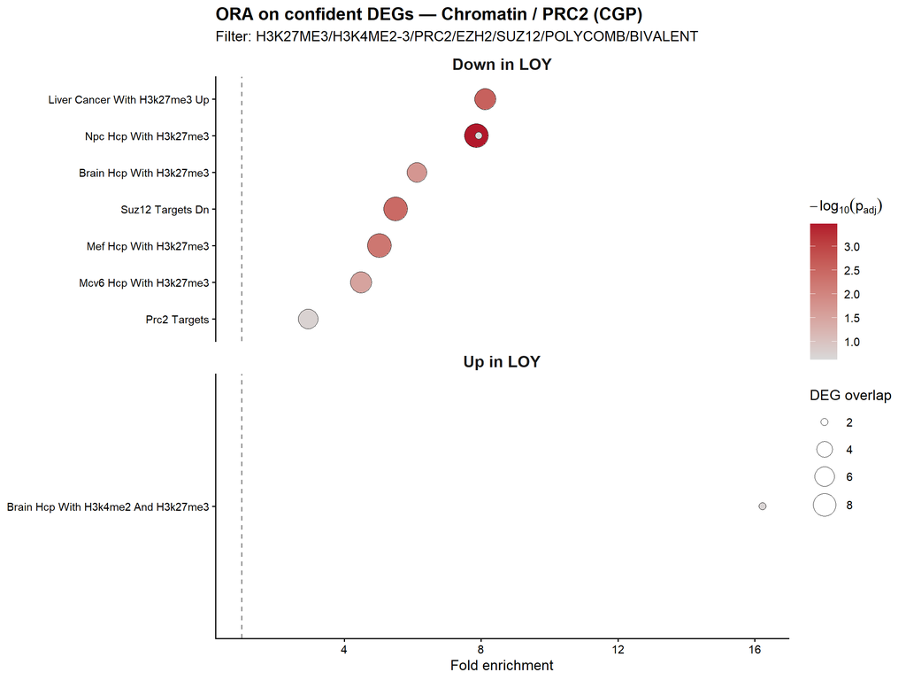

```
## Saved: robust_DEG_ORA_chromatin.(png|pdf)  [8x6 in]
```

## 10.4 Cross-design × cross-framework panel

The §10.1–§10.3 summary above is anchored on the **paired** design (the analysis of record). This sub-section asks the broader question: across both designs × {voom, treat, edgeR-QL}, how many of the 6 (design × framework) cells does each gene reach FDR<0.05? Genes flagged in ≥4/6 cells AND not CN-driven are the most robust LOY-driven candidates. (HT1080/A549 run this across 9 cells; LNCaP drops the 3 pooled-design columns because no PARENTAL arm exists.)

```
##
## Cross-design × cross-framework confident DEGs (>=4/6 cells, not CN-driven): 1
```

```
##   up:   0   down: 1
```

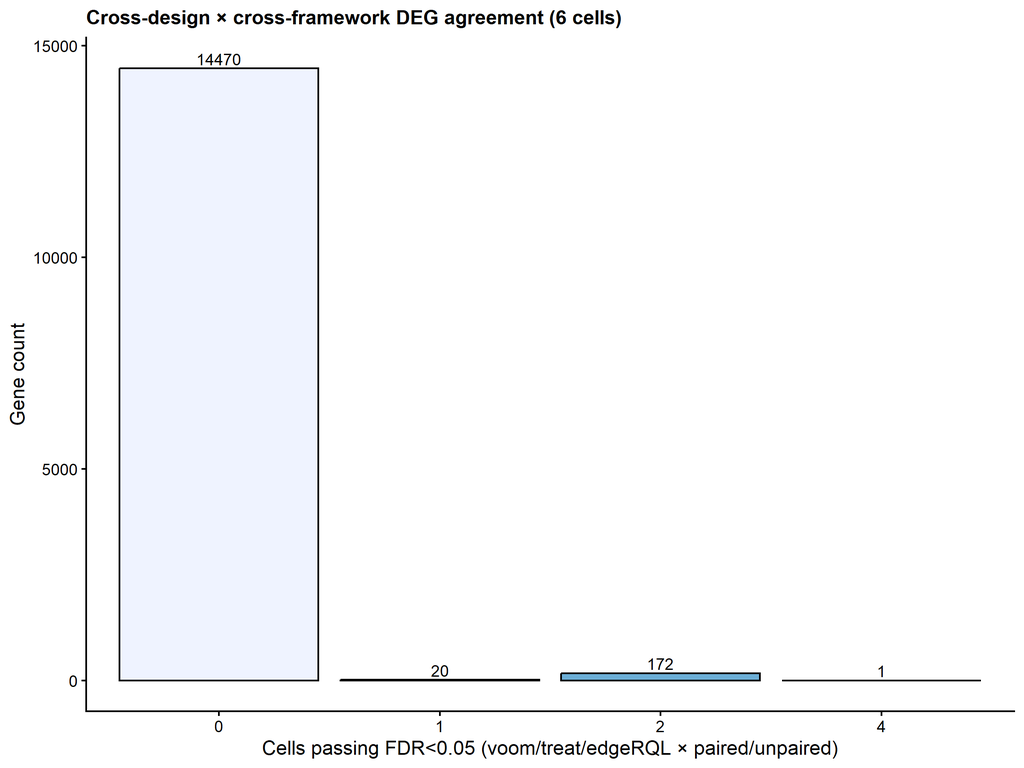

```
## Saved: robust_cross_design_agreement.(png|pdf)  [9x4 in]
```

### Top cross-design confident DEGs

Top-40 confident DEGs across designs (>=4/6 cells, not CN-driven)

| gene_name | logFC | n_pass6 | in_paralog_pair | cn_driven_flag | FDR_voom_paired | FDR_treat_paired | FDR_edgeRQL_paired | FDR_voom_unpaired | FDR_treat_unpaired | FDR_edgeRQL_unpaired |
| --- | --- | --- | --- | --- | --- | --- | --- | --- | --- | --- |
| GRHL2 | -3.96 | 4 | FALSE | FALSE | 0 | 0.007 | 0 | 0.16 | 0.464 | 0.016 |

# 11. LOY transcriptomics summary table

A consolidated per-gene table of the LOY-vs-sgCTRL effect with per-sample expression. Covers:

- Every **expressed chromosome-Y gene** (post-filter), classified by genomic region as PAR1 / PAR2 / MSY (male-specific Y)
- **PAR1 / PAR2 / MSY signature** rows — mean logCPM across each region per sample, paired-LM test (treatment + passage) on the resulting scores
- **Top-20 up + top-20 down** DEGs from the paired LOY-vs-sgCTRL contrast (FDR<ALPHA, |logFC|>LFC_THR, non-chrY)
- **Genes of interest**: DCC, XIST, and the X-paralogs of each Y gene tracked in §7

Per-sample columns are logCPM (matching how the rest of the report visualises expression). Full CSV (both CPM and logCPM aggregates, per-sample logCPM) lands at `LNCaP/DE_extended/lncap_LOY_transcriptomics_summary.csv`.

## 11.1 PAR1 / PAR2 / MSY / Yp / Yq gene panel

The classifier reuses the PAR coordinate constants defined in §1.4.5 (`PAR1_X_START` etc., `Y_CENTROMERE_MID`). The §11 panel is built from `dge_full_no_yfilter$genes` so the per-sample expression matrix built in §11.2 has matching dimensions — that’s a tighter gene set than §1.4.5’s `y_panel` (which uses the unfiltered `dge0`).

```
## Expressed Y-related genes: 24  [PAR1=14, PAR2=2, MSY=8 (MSY-Yp=3, MSY-Yq=5)]
```

## 11.2 Per-sample expression helper

## 11.3 chrY gene table

PAR1 / PAR2 / MSY genes — paired DE + group-mean expression

| gene_name | region | arm | logFC | FDR | mean_CTRL_logCPM | mean_LOY_logCPM | mean_CTRL_CPM | mean_LOY_CPM |
| --- | --- | --- | --- | --- | --- | --- | --- | --- |
| DDX3Y | MSY | Yq | -4.31 | 0.0000 | 5.68 | 1.38 | 51.3 | 2.6 |
| USP9Y | MSY | Yq | -3.73 | 0.0000 | 4.58 | 0.89 | 24.0 | 1.8 |
| EIF1AY | MSY | Yq | -4.35 | 0.0000 | 4.22 | -0.08 | 18.8 | 0.9 |
| KDM5D | MSY | Yq | -4.43 | 0.0000 | 3.66 | -0.76 | 12.8 | 0.6 |
| RPS4Y1 | MSY | Yp | -1.13 | 0.0000 | 6.92 | 5.80 | 121.8 | 55.8 |
| UTY | MSY | Yq | -4.15 | 0.0000 | 3.02 | -1.11 | 8.2 | 0.5 |
| ZFY | MSY | Yp | -0.92 | 0.0006 | 4.48 | 3.58 | 22.5 | 12.0 |
| LINC00278 | MSY | Yp | -1.34 | 0.4138 | -1.10 | -2.47 | 0.4 | 0.2 |
| P2RY8 | PAR1 | Yp | -1.76 | 0.0006 | 2.48 | 0.60 | 5.6 | 1.6 |
| SLC25A6 | PAR1 | Yp | -0.48 | 0.0198 | 9.74 | 9.26 | 856.3 | 615.8 |
| ZBED1 | PAR1 | Yp | -0.39 | 0.0437 | 6.42 | 6.03 | 85.5 | 65.4 |
| CRLF2 | PAR1 | Yp | -1.64 | 0.0486 | 0.50 | -1.05 | 1.5 | 0.5 |
| PPP2R3B | PAR1 | Yp | -0.43 | 0.0596 | 4.89 | 4.46 | 29.9 | 22.0 |
| AKAP17A | PAR1 | Yp | -0.37 | 0.0827 | 6.76 | 6.39 | 109.3 | 84.0 |
| GTPBP6 | PAR1 | Yp | -0.40 | 0.1165 | 6.70 | 6.31 | 107.4 | 79.4 |
| CD99 | PAR1 | Yp | -0.26 | 0.2370 | 8.59 | 8.32 | 384.6 | 321.3 |
| ASMTL | PAR1 | Yp | -0.26 | 0.2696 | 6.17 | 5.91 | 72.5 | 60.9 |
| DHRSX | PAR1 | Yp | -0.29 | 0.2878 | 4.64 | 4.35 | 25.0 | 20.4 |
| IL3RA | PAR1 | Yp | -0.38 | 0.7561 | 0.67 | 0.29 | 1.6 | 1.2 |
| LINC00106 | PAR1 | Yp | -0.67 | 0.8414 | -1.27 | -1.97 | 0.4 | 0.2 |
| CSF2RA | PAR1 | Yp | -0.04 | 0.9716 | 3.84 | 3.75 | 14.5 | 14.1 |
| PLCXD1 | PAR1 | Yp | -0.01 | 0.9902 | 4.86 | 4.84 | 29.3 | 28.8 |
| VAMP7 | PAR2 | Yq | 0.36 | 0.0644 | 5.56 | 5.93 | 47.5 | 61.0 |
| SPRY3 | PAR2 | Yq | 0.41 | 0.7077 | 1.15 | 1.57 | 2.3 | 3.0 |

## 11.4 PAR1 / PAR2 / MSY signature scores

Y-region signatures: PAR1, PAR2, MSY + Yp/Yq arm aggregates (mean region logCPM per sample, paired LM)

| gene_name | n_genes | logFC | PValue | FDR | mean_CTRL_logCPM | mean_LOY_logCPM |
| --- | --- | --- | --- | --- | --- | --- |
| PAR1_signature | 14 | -0.535 | 0.0328 | 0.0410 | 4.64 | 4.11 |
| PAR2_signature | 2 | 0.391 | 0.1588 | 0.1588 | 3.36 | 3.75 |
| MSY_signature | 8 | -3.032 | 0.0000 | 0.0001 | 3.93 | 0.90 |
| Yp_signature | 17 | -0.641 | 0.0269 | 0.0410 | 4.43 | 3.79 |
| Yq_signature | 7 | -2.868 | 0.0000 | 0.0001 | 3.98 | 1.12 |

## 11.4b Per-sample PAR / MSY signature scores

Compact sample-by-region table — the raw per-sample data that feeds the paired-LM tests in §11.4. Each cell is the mean logCPM across the genes in that region for that sample. Useful for spotting per-sample outliers or incomplete LOY (e.g. a “LOY” sample whose MSY mean hasn’t fully collapsed) before reading the summary statistics. LNCaP has no PARENTAL arm so this covers the entire dataset.

Per-sample Y-region mean logCPM (PAR1 / PAR2 / MSY / Yp / Yq)

|  | sample | treatment | passage | PAR1 | PAR2 | MSY | Yp | Yq |
| --- | --- | --- | --- | --- | --- | --- | --- | --- |
| LNCaP-sgCTRL-P12 | LNCaP-sgCTRL-P12 | CTRL | 12 | 4.59 | 3.11 | 3.83 | 4.37 | 3.83 |
| LNCaP-sgCTRL-P13 | LNCaP-sgCTRL-P13 | CTRL | 13 | 4.62 | 3.66 | 4.04 | 4.44 | 4.13 |
| LNCaP-sgCTRL-P14 | LNCaP-sgCTRL-P14 | CTRL | 14 | 4.72 | 3.31 | 3.93 | 4.48 | 3.99 |
| LNCaP-LOY-P12 | LNCaP-LOY-P12 | LOY | 12 | 4.16 | 3.85 | 0.83 | 3.87 | 0.98 |
| LNCaP-LOY-P13 | LNCaP-LOY-P13 | LOY | 13 | 4.17 | 3.89 | 1.01 | 3.87 | 1.23 |
| LNCaP-LOY-P14 | LNCaP-LOY-P14 | LOY | 14 | 3.98 | 3.50 | 0.86 | 3.63 | 1.13 |

```
## Wrote 6-row sample-level PAR/MSY table to lncap_LOY_sample_level_PAR_MSY.csv
```

## 11.5 Top up + top down DEGs (non-chrY)

Top 20 up + Top 20 down DEGs (paired, FDR<0.05, |logFC|>0.75, non-chrY)

| gene_name | category | logFC | FDR | mean_CTRL_logCPM | mean_LOY_logCPM |
| --- | --- | --- | --- | --- | --- |
| TACSTD2 | top_down | -0.99 | 0.0000 | 8.83 | 7.84 |
| GRHL2 | top_down | -3.96 | 0.0003 | 1.50 | -2.27 |
| AP1M2 | top_down | -0.99 | 0.0003 | 4.73 | 3.74 |
| THBD | top_down | -1.17 | 0.0006 | 3.44 | 2.26 |
| P2RY8 | top_down | -1.76 | 0.0010 | 2.48 | 0.60 |
| EBF4 | top_down | -0.93 | 0.0012 | 3.93 | 3.03 |
| LCN2 | top_down | -1.09 | 0.0012 | 3.66 | 2.79 |
| SPOCK2 | top_down | -0.85 | 0.0015 | 5.33 | 4.42 |
| SCEL | top_down | -1.12 | 0.0016 | 3.21 | 2.11 |
| RPS9 | top_down | -1.30 | 0.0020 | 7.27 | 5.89 |
| EPS8L1 | top_down | -1.21 | 0.0020 | 3.35 | 2.10 |
| HOXB9 | top_down | -0.88 | 0.0023 | 4.05 | 3.12 |
| TMC4 | top_down | -0.90 | 0.0025 | 4.90 | 4.07 |
| LTB | top_down | -1.21 | 0.0033 | 2.16 | 1.04 |
| PKIA | top_down | -1.24 | 0.0033 | 2.59 | 1.41 |
| GOLGA7B | top_down | -1.11 | 0.0033 | 2.92 | 1.80 |
| MPZL2 | top_down | -0.85 | 0.0039 | 3.80 | 2.95 |
| WFDC2 | top_down | -0.85 | 0.0045 | 3.51 | 2.69 |
| RASSF2 | top_down | -0.89 | 0.0051 | 3.48 | 2.59 |
| ATP2C2 | top_down | -0.78 | 0.0054 | 3.47 | 2.68 |
| TAF9 | top_up | 1.31 | 0.0003 | 2.43 | 3.77 |
| COL4A2 | top_up | 0.80 | 0.0006 | 4.52 | 5.32 |
| F13A1 | top_up | 0.89 | 0.0006 | 4.36 | 5.23 |
| CREB3L1 | top_up | 0.85 | 0.0009 | 4.31 | 5.15 |
| TMEM45A | top_up | 0.98 | 0.0032 | 2.66 | 3.61 |
| ABCG1 | top_up | 0.84 | 0.0037 | 2.63 | 3.46 |
| ANXA8 | top_up | 0.82 | 0.0066 | 2.74 | 3.55 |
| NPR1 | top_up | 0.85 | 0.0066 | 2.76 | 3.55 |
| IRX5 | top_up | 0.89 | 0.0077 | 2.29 | 3.16 |
| BMP7 | top_up | 0.75 | 0.0080 | 2.88 | 3.62 |
| ADAM12 | top_up | 1.01 | 0.0172 | 1.79 | 2.86 |
| RSPO3 | top_up | 1.19 | 0.0177 | 0.96 | 2.21 |
| CNTN1 | top_up | 1.07 | 0.0192 | 1.05 | 2.22 |
| FAT2 | top_up | 3.03 | 0.0202 | -3.63 | -1.21 |
| PDE10A | top_up | 2.38 | 0.0338 | -2.51 | -0.16 |

## 11.6 Genes of interest (DCC, XIST, X-paralogs)

```
## GOI not detected post-filter: DCC, XIST, NLGN4X
```

Genes of interest (DCC, XIST, X-paralogs)

| gene_name | region | logFC | FDR | mean_CTRL_logCPM | mean_LOY_logCPM |
| --- | --- | --- | --- | --- | --- |
| DDX3X | chrX | 0.16 | 0.6091 | 8.60 | 8.77 |
| EIF1AX | chrX | 0.11 | 0.8359 | 6.96 | 7.07 |
| KDM5C | chrX | 0.14 | 0.7428 | 7.41 | 7.55 |
| KDM6A | chrX | 0.11 | 0.8476 | 4.67 | 4.79 |
| PRKX | chrX | 0.05 | 0.9632 | 4.75 | 4.81 |
| RPS4X | chrX | -0.07 | 0.9069 | 9.78 | 9.71 |
| TMSB4X | chrX | 0.00 | 0.9954 | 8.39 | 8.38 |
| USP9X | chrX | 0.24 | 0.3142 | 7.73 | 7.97 |
| ZFX | chrX | 0.18 | 0.6535 | 4.89 | 5.08 |

## 11.7 Combined export

```
## Wrote 73 rows to lncap_LOY_transcriptomics_summary.csv
```